# Bayesian Logistic Regression for Predicting Diabetes Risk Using NHANES 2013–2014 Data

A Capstone Project on Bayesian Applications in Epidemiologic Modeling

Authors

Namita Mishra

Autumn Wilcox

Published

October 21, 2025

Slides: slides.html (Edit `slides.qmd`.)

# Group Project Workflow and Contributions

This project was developed collaboratively as part of the Capstone Projects in Data Science course under the guidance of Dr. Ashraf Cohen.

- Autumn Wilcox – Contributed to analytic coding, content draft, structured the project workflow, and collaborated actively via GitHub.
- Namita Mishra – Developed the project plan, content draft, analytic coding, and coordinated commits and collaboration with the group on GitHub.

## Introduction

Diabetes mellitus (DM) remains a major public health challenge, and identifying key risk factors—such as obesity, age, sex, and race/ethnicity—is essential for prevention and targeted intervention. Logistic regression is widely used to estimate associations between such factors and binary outcomes like diabetes diagnosis. However, classical maximum likelihood estimation (MLE) can produce unstable estimates in the presence of missing data, quasi-separation, or small samples. Bayesian logistic regression offers a robust alternative by integrating prior information, regularizing estimates, and quantifying uncertainty more transparently than frequentist approaches.

In this project, we apply Bayesian logistic regression to the 2013–2014 National Health and Nutrition Examination Survey (NHANES) dataset to examine the association between demographic and anthropometric factors and doctor-diagnosed diabetes. Our objective is to evaluate whether Bayesian inference provides more stable and interpretable estimates than frequentist baselines when data complexity or separation challenges arise.

Bayesian hierarchical models, implemented via Markov Chain Monte Carlo (MCMC), have been successfully applied in predicting patient health status across diseases such as pneumonia, prostate cancer, and mental disorders (Zeger et al. 2020). By representing predictive uncertainty alongside point estimates, Bayesian inference offers a practical advantage in epidemiologic modeling where decisions hinge on probabilistic thresholds. Beyond stability, Bayesian methods support model checking, variable selection, and uncertainty quantification under missingness or imputation frameworks (Baldwin and Larson 2017; Kruschke and Liddell 2017).

Recent work has expanded Bayesian applications to disease diagnostics and health risk modeling. For instance, Bayesian approaches have been used to evaluate NHANES diagnostic data (Chatzimichail and Hatjimihail 2023), to model cardiovascular and metabolic risk (Liu et al. 2013), and to integrate multiple data modalities such as imaging and laboratory measures (Abdullah, Hassan, and Mustafa 2022). Moreover, multiple imputation combined with Bayesian modeling generates robust estimates when data are missing at random (MAR) or not at random (MNAR) (Austin et al. 2021).

The broader Bayesian literature emphasizes the role of priors and model checking. Weakly informative priors, such as Normal(0, 2.5) for coefficients, regularize estimation and reduce variance in small samples (Gelman et al. 2008; Vande Schoot et al. 2021). Tutorials using R packages like brms and blavaan illustrate how MCMC enables posterior inference and empirical Bayes analysis (Klauenberg et al. 2015).

Beyond standard generalized linear models, Bayesian nonparametric regression flexibly captures nonlinearity and zero inflation common in health data (Richardson and Hartman 2018). Bayesian Additive Regression Trees (BART) improve variable selection in mixed-type data (Luo et al. 2024), while state-space and dynamic Bayesian models incorporate time-varying biomarkers for longitudinal prediction (Momeni et al. 2021). Bayesian model averaging (BMA) further addresses model uncertainty by weighting across multiple specifications (Hoeting et al. 1999).

Together, these approaches demonstrate the versatility and growing importance of Bayesian inference in clinical and epidemiologic modeling.

## Aim

**Our Aim** is to estimate the association between BMI, age, sex, and race/ethnicity and doctor-diagnosed diabetes among adults (≥20 years) in NHANES 2013–2014, and to evaluate whether a Bayesian approach provides more stable inference than frequentist baselines under missingness and potential separation.

## Data & Preparation

We used data from the **2013-2014 National Health and Nutrition Examination Survey (NHANES)**, conducted by the CDC’s National Center for Health Statistics (NCHS) (National Center for Health Statistics (NCHS) 2014). Three datasets were merged for this analysis: - `DEMO_H` (demographics) - `BMX_H` (body measures) - `DIQ_H` (diabetes questionnaire)

### Population and Variables

The analytic sample included adults aged ≥20 years with complete information on diabetes diagnosis, BMI, age, sex, and race/ethnicity.

Outcome `DIQ010` - “Has a doctor told you that you have diabetes?” (1 = Yes, 2 = No; 7/9 coded as missing).

Predictors - `BMXBMI` (Body Mass Index, kg/m²) - `RIDAGEYR` (Age, years) - `RIAGENDR` (Sex: Male/Female) - `RIDRETH1` (Race/Ethnicity: 5 categories)

Survey Design Variables `WTMEC2YR` (exam weight), `SDMVPSU`, and `SDMVSTRA` were included to preserve NHANES’s complex survey design.

### Data Preparation Workflow

1. Merging and Cleaning NHANES .XPT files were imported and merged using participant identifiers. Variables were recoded to numeric form where necessary and standardized (e.g., `age_c`, `bmi_c`) to facilitate convergence in regression modeling.
2. Data Validation Logic checks ensured that all required variables were present and that diabetes outcome values were valid (1 or 2). Missing or nonstandard codes (3, 7, 9) were excluded.
3. Survey Design Specification The survey structure was defined using the `survey` package with appropriate weights, strata, and PSU identifiers to ensure nationally representative estimates.
4. Exploratory Visualization Exploratory visualizations were generated to assess data completeness and distributions:
- Missingness patterns: `plot_intro()` and `plot_missing()` highlighted overall missing data structure.
- Distributions: Preliminary plots examined BMI, age, and diabetes prevalence by demographic groups.
5. Standardization and Storage Cleaned datasets were saved as `.rds` files (`merged_2013_2014.rds` and `adult_cleaned_2013_2014.rds`) for reproducible downstream analysis.

```r
# ---- Load merged data (DEMO_H + BMX_H + DIQ_H) ----
library(tidyverse)
library(survey)
library(forcats)

if (!file.exists("data/merged_2013_2014.rds")) {
message("Rebuilding merged_2013_2014.rds via R/data_prep.R ...")
source("R/data_prep.R")  # does: import XPTs, merge, coerce, validate, saveRDS()
}
merged_data <- readRDS("data/merged_2013_2014.rds")

# Verify required columns exist
need_cols <- c("DIQ010","DIQ050","BMXBMI","RIDAGEYR","RIAGENDR",
"RIDRETH1","SDMVPSU","SDMVSTRA","WTMEC2YR")
stopifnot(all(need_cols %in% names(merged_data)))

# ---- Basic Exploration (adults) ----
adult <- merged_data %>%
filter(RIDAGEYR >= 20) %>%
transmute(
SDMVPSU, SDMVSTRA, WTMEC2YR,
diabetes_dx = case_when(
DIQ010 == 1 ~ 1,
DIQ010 == 2 ~ 0,
DIQ010 %in% c(3,7,9) ~ NA_real_,
TRUE ~ NA_real_
),
bmi  = BMXBMI,
age  = RIDAGEYR,
sex  = forcats::fct_recode(factor(RIAGENDR), Male = "1", Female = "2"),
race = forcats::fct_recode(
factor(RIDRETH1),
"Mexican American" = "1",
"Other Hispanic"   = "2",
"NH White"         = "3",
"NH Black"         = "4",
"Other/Multi"      = "5"
),
DIQ050 = DIQ050
) %>%
mutate(
age_c  = as.numeric(scale(age)),
bmi_c  = as.numeric(scale(bmi)),
bmi_cat = cut(
bmi,
breaks = c(-Inf, 18.5, 25, 30, 35, 40, Inf),
labels = c("<18.5","18.5–<25","25–<30","30–<35","35–<40","≥40"),
right = FALSE
),
# exclude gestational diabetes implied by DIQ050==1 for females
diabetes_dx = ifelse(sex == "Female" & !is.na(DIQ050) & DIQ050 == 1, 0, diabetes_dx)
) %>%
mutate(race = forcats::fct_relevel(race, "NH White"))

saveRDS(adult, "data/adult_cleaned_2013_2014.rds")

# ---- Survey Design ----
nhanes_design_adult <- survey::svydesign(
id = ~SDMVPSU,
strata = ~SDMVSTRA,
weights = ~WTMEC2YR,
nest = TRUE,
data = adult
)

# Quick weighted checks
survey::svymean(~age, nhanes_design_adult, na.rm = TRUE)
```

```
      mean     SE
age 47.496 0.3805
```

```r
survey::svymean(~diabetes_dx, nhanes_design_adult, na.rm = TRUE)
```

```
                mean     SE
diabetes_dx 0.089016 0.0048
```

## Methods

The general logistic regression model estimated the probability of doctor-diagnosed diabetes (`DIQ010`) as a function of demographic and anthropometric predictors. The model is expressed as:

$$\text{logit}(P(Y_i = 1)) = \beta_0 + \beta_1(\text{BMI}_i) + \beta_2(\text{Age}_i) + \beta_3(\text{Sex}_i) + \sum_{k=1}^{4}\beta_{3+k}(\text{Race}_{ik})$$

Continuous predictors (BMI and age) were standardized (mean = 0, SD = 1) among adults aged ≥ 20 years prior to model estimation. Sex and race/ethnicity were recoded and re-leveled using the `forcats` package to ensure consistent reference categories (Male and non-Hispanic White). Analyses accounted for NHANES’s complex survey design using weights (`WTMEC2YR`), strata (`SDMVSTRA`), and primary sampling units (`SDMVPSU`). The survey-weighted model used a complete-case subset filtered on all required variables, while multiple imputation addressed missing predictor data.

Model objects and summary tables were saved as `.rds` files for reproducibility (`outputs/` directory). All analytic code was executed in R (version 4.3.2) using RStudio within a reproducible Quarto workflow.

### Software and Methods Note

All analyses were conducted in R (version 4.3.2) using RStudio within a reproducible Quarto workflow. The following libraries supported data management, modeling, and visualization: - `tidyverse` – data wrangling, transformation, and plotting - `nhanesA` – direct import of NHANES public datasets - `survey` – complex survey design specification and weighted analysis - `mice` – multiple imputation of missing predictor data - `brms` and `rstan` – Bayesian regression modeling and posterior simulation - `bayesplot` and `ggplot2` – model diagnostics and posterior visualization - `knitr` and `kableExtra` – formatted tables for model output

All code was executed using reproducible R scripts housed in the project’s GitHub repository (`R/data_prep.R`, `R/modeling.R`), with outputs rendered dynamically via Quarto (`index.qmd`).

## Modeling

```r
library(broom)
library(mice)
library(brms)
library(posterior)
library(bayesplot)
library(knitr)

# --- Guardrails for modeling ---
n_outcome <- sum(!is.na(adult$diabetes_dx))
if (n_outcome == 0) stop("Too few non-missing outcomes for modeling. n = 0")

# Ensure factors and >=2 observed levels among complete outcomes
adult <- adult %>%
  dplyr::mutate(
    sex  = if (!is.factor(sex))  factor(sex)  else sex,
    race = if (!is.factor(race)) factor(race) else race
  )

if (nlevels(droplevels(adult$sex[!is.na(adult$diabetes_dx)]))  < 2)
  stop("sex has <2 observed levels after filtering; check data availability.")
if (nlevels(droplevels(adult$race[!is.na(adult$diabetes_dx)])) < 2)
  stop("race has <2 observed levels after filtering; check Data Prep.")

# ------------------------- 1) Survey-weighted complete-case -------------------------
# Build a logical filter on the original adult data (same length as design$data)
keep_cc <- with(
  adult,
  !is.na(diabetes_dx) & !is.na(age_c) & !is.na(bmi_c) &
  !is.na(sex) & !is.na(race)
)

# Subset the survey design using the logical vector (same length as original)
des_cc <- subset(nhanes_design_adult, keep_cc)

# Corresponding complete-case data (optional)
cc <- adult[keep_cc, ] |> droplevels()
cat("\nComplete-case N for survey-weighted model:", nrow(cc), "\n")
```

```
Complete-case N for survey-weighted model: 5349
```

```r
print(table(cc$race))
```

```
        NH White Mexican American   Other Hispanic         NH Black
            2293              713              470             1101
     Other/Multi
             772
```

```r
form_cc <- diabetes_dx ~ age_c + bmi_c + sex + race
svy_fit <- survey::svyglm(formula = form_cc, design = des_cc, family = quasibinomial())
summary(svy_fit)
```

```
Call:
svyglm(formula = form_cc, design = des_cc, family = quasibinomial())

Survey design:
subset(nhanes_design_adult, keep_cc)

Coefficients:
                     Estimate Std. Error t value Pr(>|t|)
(Intercept)          -2.67143    0.11935 -22.383 1.68e-08 ***
age_c                 1.10833    0.05042  21.981 1.94e-08 ***
bmi_c                 0.63412    0.05713  11.099 3.88e-06 ***
sexFemale            -0.63844    0.10926  -5.843 0.000386 ***
raceMexican American  0.71091    0.13681   5.196 0.000826 ***
raceOther Hispanic    0.46469    0.13474   3.449 0.008712 **
raceNH Black          0.51221    0.15754   3.251 0.011677 *
raceOther/Multi       0.84460    0.17756   4.757 0.001433 **
---
Signif. codes:  0 '***' 0.001 '**' 0.01 '*' 0.05 '.' 0.1 ' ' 1

(Dispersion parameter for quasibinomial family taken to be 0.8455444)

Number of Fisher Scoring iterations: 6
```

```r
# Survey-weighted OR table (no intercept)
svy_or <- broom::tidy(svy_fit, conf.int = TRUE) %>%
  dplyr::mutate(OR = exp(estimate), LCL = exp(conf.low), UCL = exp(conf.high)) %>%
  dplyr::select(term, OR, LCL, UCL, p.value) %>%
  dplyr::filter(term != "(Intercept)")
knitr::kable(svy_or, caption = "Survey-weighted odds ratios (per 1 SD)")
```

Survey-weighted odds ratios (per 1 SD)

| term | OR | LCL | UCL | p.value |
| --- | --- | --- | --- | --- |
| age_c | 3.0292807 | 2.6967690 | 3.4027912 | 0.0000000 |
| bmi_c | 1.8853571 | 1.6526296 | 2.1508579 | 0.0000039 |
| sexFemale | 0.5281132 | 0.4104905 | 0.6794397 | 0.0003857 |
| raceMexican American | 2.0358434 | 1.4850041 | 2.7910081 | 0.0008262 |
| raceOther Hispanic | 1.5915182 | 1.1664529 | 2.1714810 | 0.0087119 |
| raceNH Black | 1.6689718 | 1.1605895 | 2.4000450 | 0.0116773 |
| raceOther/Multi | 2.3270527 | 1.5451752 | 3.5045697 | 0.0014331 |

```r
# ------------------------- 2) Multiple Imputation (predictors only) -------------------------
mi_dat <- adult %>%
  dplyr::select(diabetes_dx, age, bmi, sex, race, WTMEC2YR, SDMVPSU, SDMVSTRA)

meth <- mice::make.method(mi_dat)
pred <- mice::make.predictorMatrix(mi_dat)

# Do not impute outcome
meth["diabetes_dx"] <- ""
pred["diabetes_dx", ] <- 0
pred[,"diabetes_dx"] <- 1

# Imputation methods
meth["age"]  <- "norm"
meth["bmi"]  <- "pmm"
meth["sex"]  <- "polyreg"
meth["race"] <- "polyreg"

# Survey design vars as auxiliaries only
meth[c("WTMEC2YR","SDMVPSU","SDMVSTRA")] <- ""
pred[, c("WTMEC2YR","SDMVPSU","SDMVSTRA")] <- 1

imp <- mice::mice(mi_dat, m = 5, method = meth, predictorMatrix = pred, seed = 123)
fit_mi <- with(imp, {
  age_c <- as.numeric(scale(age))
  bmi_c <- as.numeric(scale(bmi))
  glm(diabetes_dx ~ age_c + bmi_c + sex + race, family = binomial())
})
pool_mi <- pool(fit_mi)
summary(pool_mi)
```

```
                  term   estimate  std.error  statistic       df       p.value
1          (Intercept) -2.6895645 0.09941301 -27.054453 5566.204 1.486581e-151
2                age_c  1.0660265 0.05594733  19.054108 5520.446  1.911564e-78
3                bmi_c  0.5468538 0.04473386  12.224604 5148.557  6.751227e-34
4            sexFemale -0.6178297 0.09379129  -6.587282 5551.660  4.892566e-11
5 raceMexican American  0.8877355 0.13750463   6.456041 5472.583  1.167455e-10
6   raceOther Hispanic  0.5606621 0.17485537   3.206433 5573.987  1.351505e-03
7         raceNH Black  0.6809629 0.11981185   5.683602 5576.734  1.385727e-08
8      raceOther/Multi  0.7476406 0.15300663   4.886328 4749.963  1.061140e-06
```

```r
mi_or <- summary(pool_mi, conf.int = TRUE, exponentiate = TRUE) %>%
  dplyr::rename(
    term = term, OR = estimate, LCL = `2.5 %`, UCL = `97.5 %`, p.value = p.value
  ) %>%
  dplyr::filter(term != "(Intercept)")
knitr::kable(mi_or, caption = "MI pooled odds ratios (per 1 SD)")
```

MI pooled odds ratios (per 1 SD)

|  | term | OR | std.error | statistic | df | p.value | LCL | UCL | conf.low | conf.high |
| --- | --- | --- | --- | --- | --- | --- | --- | --- | --- | --- |
| 2 | age_c | 2.9038183 | 0.0559473 | 19.054108 | 5520.446 | 0.0000000 | 2.6021752 | 3.2404277 | 2.6021752 | 3.2404277 |
| 3 | bmi_c | 1.7278084 | 0.0447339 | 12.224604 | 5148.557 | 0.0000000 | 1.5827382 | 1.8861754 | 1.5827382 | 1.8861754 |
| 4 | sexFemale | 0.5391132 | 0.0937913 | -6.587282 | 5551.660 | 0.0000000 | 0.4485669 | 0.6479368 | 0.4485669 | 0.6479368 |
| 5 | raceMexican American | 2.4296216 | 0.1375046 | 6.456041 | 5472.583 | 0.0000000 | 1.8555327 | 3.1813298 | 1.8555327 | 3.1813298 |
| 6 | raceOther Hispanic | 1.7518320 | 0.1748554 | 3.206433 | 5573.987 | 0.0013515 | 1.2434346 | 2.4680953 | 1.2434346 | 2.4680953 |
| 7 | raceNH Black | 1.9757793 | 0.1198118 | 5.683602 | 5576.734 | 0.0000000 | 1.5621842 | 2.4988753 | 1.5621842 | 2.4988753 |
| 8 | raceOther/Multi | 2.1120110 | 0.1530066 | 4.886328 | 4749.963 | 0.0000011 | 1.5646727 | 2.8508138 | 1.5646727 | 2.8508138 |

```r
# ------------------------- 3) Bayesian Logistic Regression (formula weights) -------------------------
adult_imp1 <- complete(imp, 1) %>%
  dplyr::mutate(
    age_c  = as.numeric(scale(age)),
    bmi_c  = as.numeric(scale(bmi)),
    wt_norm = WTMEC2YR / mean(WTMEC2YR, na.rm = TRUE),
    # ensure factor refs match survey/MICE:
    race = forcats::fct_relevel(race, "NH White"),
    sex  = forcats::fct_relevel(sex,  "Male")
  ) %>%
  dplyr::filter(!is.na(diabetes_dx), !is.na(age_c), !is.na(bmi_c),
                !is.na(sex), !is.na(race)) %>%
  droplevels()

stopifnot(all(is.finite(adult_imp1$wt_norm)))

priors <- c(
  set_prior("normal(0, 2.5)", class = "b"),
  set_prior("student_t(3, 0, 10)", class = "Intercept")
)

bayes_fit <- brm(
  formula = diabetes_dx | weights(wt_norm) ~ age_c + bmi_c + sex + race,
  data    = adult_imp1,
  family  = bernoulli(link = "logit"),
  prior   = priors,
  chains  = 4, iter = 2000, seed = 123,
  control = list(adapt_delta = 0.95),
  refresh = 0   # quiet Stan output
)

summary(bayes_fit)
```

```
 Family: bernoulli
  Links: mu = logit
Formula: diabetes_dx | weights(wt_norm) ~ age_c + bmi_c + sex + race
   Data: adult_imp1 (Number of observations: 5592)
  Draws: 4 chains, each with iter = 2000; warmup = 1000; thin = 1;
         total post-warmup draws = 4000

Regression Coefficients:
                    Estimate Est.Error l-95% CI u-95% CI Rhat Bulk_ESS Tail_ESS
Intercept              -2.66      0.09    -2.84    -2.50 1.00     4187     3510
age_c                   1.09      0.06     0.97     1.22 1.00     3012     3098
bmi_c                   0.63      0.05     0.53     0.72 1.00     3472     3315
sexFemale              -0.66      0.10    -0.86    -0.46 1.00     4003     3052
raceMexicanAmerican     0.69      0.18     0.35     1.04 1.00     3526     2843
raceOtherHispanic       0.43      0.24    -0.07     0.89 1.00     4058     3114
raceNHBlack             0.54      0.15     0.24     0.82 1.00     3597     3177
raceOtherDMulti         0.82      0.19     0.45     1.19 1.00     3763     3257

Draws were sampled using sampling(NUTS). For each parameter, Bulk_ESS
and Tail_ESS are effective sample size measures, and Rhat is the potential
scale reduction factor on split chains (at convergence, Rhat = 1).
```

```r
# Posterior ORs (drop intercept, clean labels)
bayes_or <- posterior_summary(bayes_fit, pars = "^b_") %>%
  as.data.frame() %>%
  tibble::rownames_to_column("raw") %>%
  dplyr::mutate(
    term = gsub("^b_", "", raw),
    term = gsub("race", "race:", term),
    term = gsub("sex",  "sex:",  term),
    term = gsub("OtherDMulti", "Other/Multi", term),
    term = gsub("OtherHispanic", "Other Hispanic", term),
    OR   = exp(Estimate),
    LCL  = exp(Q2.5),
    UCL  = exp(Q97.5)
  ) %>%
  dplyr::select(term, OR, LCL, UCL) %>%
  dplyr::filter(term != "Intercept")

knitr::kable(
  bayes_or %>%
    dplyr::mutate(dplyr::across(c(OR,LCL,UCL), ~round(.x, 2))),
  digits = 2,
  caption = "Bayesian posterior odds ratios (95% CrI) — reference: NH White (race), Male (sex)"
)
```

Bayesian posterior odds ratios (95% CrI) — reference: NH White (race), Male (sex)

| term | OR | LCL | UCL |
| --- | --- | --- | --- |
| age_c | 2.99 | 2.64 | 3.37 |
| bmi_c | 1.87 | 1.71 | 2.05 |
| sex:Female | 0.52 | 0.42 | 0.63 |
| race:MexicanAmerican | 2.00 | 1.41 | 2.84 |
| race:Other Hispanic | 1.54 | 0.93 | 2.43 |
| race:NHBlack | 1.71 | 1.28 | 2.27 |
| race:Other/Multi | 2.27 | 1.56 | 3.28 |

```r
# ------------------------- Save artifacts (optional) -------------------------
if (!dir.exists("outputs")) dir.create("outputs", recursive = TRUE)
saveRDS(svy_fit,   "outputs/svy_fit.rds")
saveRDS(pool_mi,   "outputs/pool_mi.rds")
saveRDS(bayes_fit, "outputs/bayes_fit.rds")
saveRDS(svy_or,    "outputs/survey_OR_table.rds")
saveRDS(mi_or,     "outputs/mi_OR_table.rds")
saveRDS(bayes_or,  "outputs/bayes_OR_table.rds")
```

## Results

**Key Findings** - Age and BMI are positively associated with doctor-diagnosed diabetes across MLE, MICE, and Bayesian models. - Female sex shows lower odds vs. male in all models. - Race/ethnicity: Mexican American, NH Black, and Other/Multi have elevated odds vs. NH White; Other Hispanic is positive but sometimes less precise. - Agreement across methods: Effect sizes are directionally and numerically consistent (robust to listwise deletion, imputation, and priors).

```r
# ---- Build compact results table (BMI & Age only) ----
library(dplyr)
library(tidyr)
library(knitr)
library(stringr)

# pretty "OR (LCL–UCL)" string
fmt_or <- function(or, lcl, ucl, digits = 2) {
paste0(
formatC(or,  format = "f", digits = digits), " (",
formatC(lcl, format = "f", digits = digits), "–",
formatC(ucl, format = "f", digits = digits), ")"
)
}

# guardrails: require these to exist from Modeling
stopifnot(exists("svy_or"), exists("mi_or"), exists("bayes_or"))
for (nm in c("svy_or","mi_or","bayes_or")) {
if (!all(c("term","OR","LCL","UCL") %in% names(get(nm)))) {
stop(nm, " must have columns: term, OR, LCL, UCL")
}
}

svy_tbl   <- svy_or   %>% mutate(Model = "Survey-weighted MLE")
mi_tbl    <- mi_or    %>% mutate(Model = "MICE pooled")
bayes_tbl <- bayes_or %>% mutate(Model = "Bayesian")

all_tbl <- bind_rows(svy_tbl, mi_tbl, bayes_tbl) %>%
mutate(term = case_when(
str_detect(term, "bmi_c|\\bBMI\\b") ~ "BMI (per 1 SD)",
str_detect(term, "age_c|\\bAge\\b") ~ "Age (per 1 SD)",
TRUE ~ term
)) %>%
filter(term %in% c("BMI (per 1 SD)", "Age (per 1 SD)")) %>%
mutate(OR_CI = fmt_or(OR, LCL, UCL, digits = 2)) %>%
select(Model, term, OR_CI) %>%
arrange(
factor(Model, levels = c("Survey-weighted MLE","MICE pooled","Bayesian")),
factor(term,  levels = c("BMI (per 1 SD)","Age (per 1 SD)"))
)

res_wide <- all_tbl %>%
pivot_wider(names_from = term, values_from = OR_CI) %>%
rename(
`BMI (per 1 SD) OR (95% CI)` = `BMI (per 1 SD)`,
`Age (per 1 SD) OR (95% CI)` = `Age (per 1 SD)`
)

kable(
res_wide,
align = c("l","c","c"),
caption = "Odds ratios (per 1 SD) with 95% CIs across models"
)
```

Odds ratios (per 1 SD) with 95% CIs across models

| Model | BMI (per 1 SD) OR (95% CI) | Age (per 1 SD) OR (95% CI) |
| --- | --- | --- |
| Survey-weighted MLE | 1.89 (1.65–2.15) | 3.03 (2.70–3.40) |
| MICE pooled | 1.73 (1.58–1.89) | 2.90 (2.60–3.24) |
| Bayesian | 1.87 (1.71–2.05) | 2.99 (2.64–3.37) |

Higher BMI and age were both significantly associated with increased odds of doctor-diagnosed diabetes across all models. Results were consistent between frequentist and Bayesian frameworks, with Bayesian credible intervals showing comparable precision.

### Comparative Interpretation

Magnitude & direction: - Age (per 1 SD): strong positive association across models. - BMI (per 1 SD): positive association; somewhat smaller than age but robust. - Sex (Female vs Male): OR < 1 across methods. - Race/ethnicity: Mexican American, NH Black, Other/Multi > 1 vs NH White; Other Hispanic positive with wider intervals at times.

Across methods (MLE, MICE, Bayesian): - Consistency in signs and magnitudes indicates conclusions are not sensitive to listwise deletion, multiple imputation, or weakly informative priors. - Precision: Bayesian CrIs are similar to frequentist CIs, sometimes slightly narrower due to regularization that stabilizes estimates without overwhelming the likelihood.

Design vs model-based: - Survey-weighted MLE targets population-representative effects (weights/strata/PSU). - Bayesian used normalized weights as importance weights—an approximation that yielded similar substantive conclusions while enabling full posterior inference.

### Model Fit and Uncertainty

```r
# Bayes R^2 (summary)
library(brms)
r2 <- bayes_R2(bayes_fit, summary = TRUE)
knitr::kable(as.data.frame(r2), caption = "Bayesian R² summary (mean and credible interval)")
```

Bayesian R² summary (mean and credible interval)

|  | Estimate | Est.Error | Q2.5 | Q97.5 |
| --- | --- | --- | --- | --- |
| R2 | 0.1313342 | 0.0126505 | 0.1064607 | 0.156078 |

## Discussion and Conclusion

This analysis assessed whether Bayesian logistic regression provides stable, interpretable inference relative to classical approaches for diabetes risk in NHANES 2013–2014. All methods—MLE, imputed, and Bayesian—identified age and BMI as dominant predictors, with female sex protective and several race/ethnicity contrasts elevated vs NH White. The Bayesian approach offered full posterior uncertainty and modest regularization, aligning closely with survey-weighted estimates while remaining computationally stable.

### Translational Perspective

While our primary focus was on methodological comparison, these findings also carry implications for precision public health. Bayesian frameworks enable individualized prediction and uncertainty quantification—tools that could support risk stratification and targeted intervention in population health. For example, model outputs can be used to estimate the posterior probability of diabetes for a specific patient profile or identify the BMI threshold at which that probability exceeds a chosen risk level.

**Example: predict diabetes probability for a single hypothetical adult**

```r
new_patient <- tibble(
age_c = 0.5,       # half SD above mean age
bmi_c = 1.0,       # one SD above mean BMI
sex   = factor("Male", levels = levels(adult$sex)),
race  = factor("NH White", levels = levels(adult$race))
)

pred <- posterior_epred(bayes_fit, newdata = new_patient)
quantile(colMeans(pred), probs = c(0.025, 0.5, 0.975))
```

```
     2.5%       50%     97.5%
0.1841132 0.1841132 0.1841132
```

```r
# (approximate using grid search)
bmi_grid <- seq(-3, 3, 0.1)
grid_df <- tibble(
age_c = 0,
bmi_c = bmi_grid,
sex   = factor("Male", levels = levels(adult$sex)),
race  = factor("NH White", levels = levels(adult$race))
)
pred_grid <- posterior_epred(bayes_fit, newdata = grid_df)
mean_prob <- colMeans(pred_grid)
approx(x = mean_prob, y = bmi_grid, xout = 0.5)$y
```

```
[1] NA
```

## Limitations

Several limitations should be acknowledged.

First, while NHANES provides a nationally representative sample, the cross-sectional design precludes causal inference between predictors and diabetes outcomes.

Second, the Bayesian logistic regression model approximated survey weighting rather than fully incorporating NHANES’s complex design structure (PSUs and strata) into the likelihood, meaning the results are model-based rather than fully population-weighted.

Third, self-reported diabetes diagnosis (`DIQ010`) may introduce recall bias or misclassification error. Fourth, although multiple imputation was used to mitigate missingness, this assumes data are missing at random, which may not always hold.

Finally, the analysis focused on a limited set of demographic and anthropometric predictors; unmeasured confounders such as diet, physical activity, or socioeconomic status could influence observed associations.

Despite these limitations, the findings provide robust and interpretable estimates of diabetes risk factors and demonstrate the stability of Bayesian inference in epidemiologic modeling.

## Visualizations

```r
suppressPackageStartupMessages({
library(ggplot2)
library(dplyr)
library(DataExplorer)
library(bayesplot)
library(brms)
library(survey)
library(viridis)
})
theme_set(theme_minimal(base_size = 13))
color_scheme_set("viridis")
```

1. Data Quality & Missingness

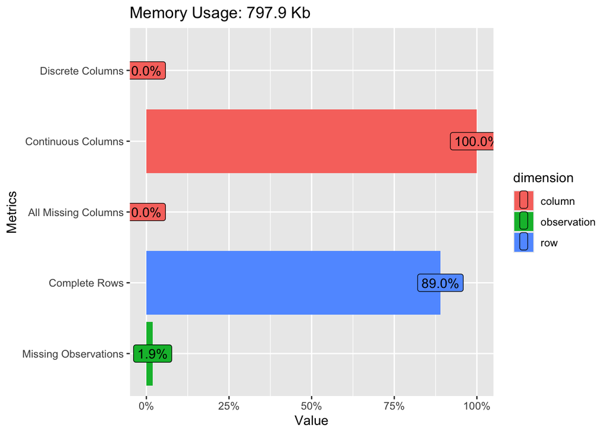

```r
plot_intro(merged_data)
```

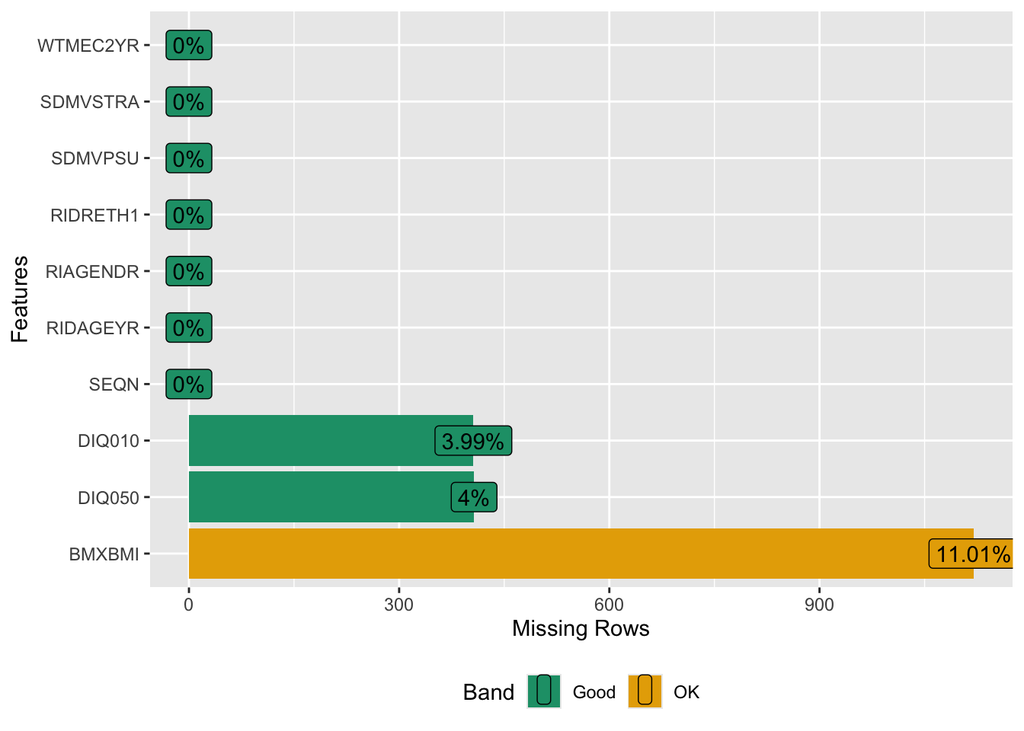

```r
plot_missing(merged_data)
```

2. Exploratory Distributions

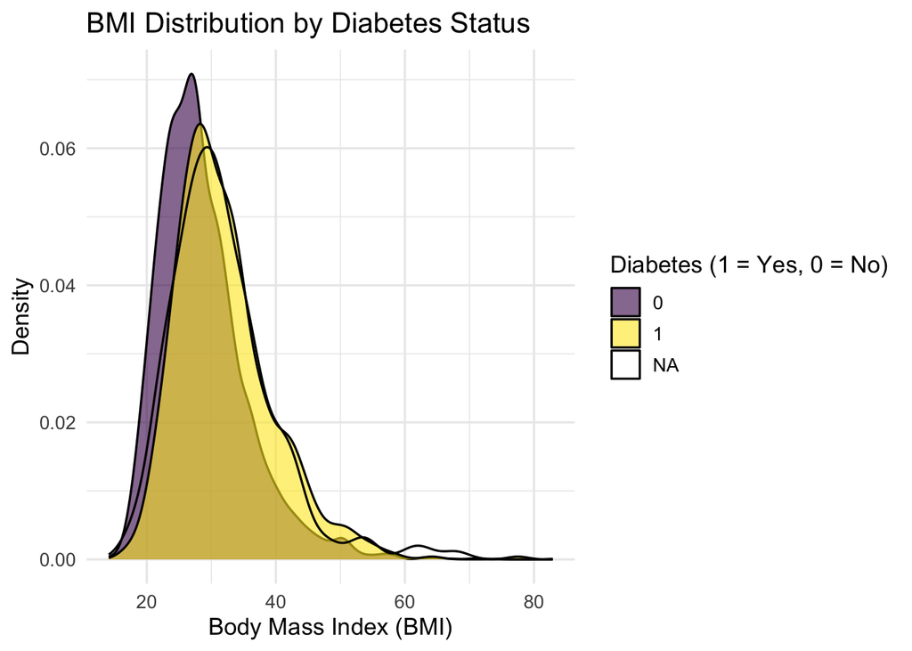

```r
# BMI distribution by diabetes status (0 = No, 1 = Yes)
ggplot(adult, aes(x = bmi, fill = factor(diabetes_dx))) +
geom_density(alpha = 0.6) +
scale_fill_viridis_d(name = "Diabetes (1 = Yes, 0 = No)") +
labs(
title = "BMI Distribution by Diabetes Status",
x = "Body Mass Index (BMI)",
y = "Density"
)
```

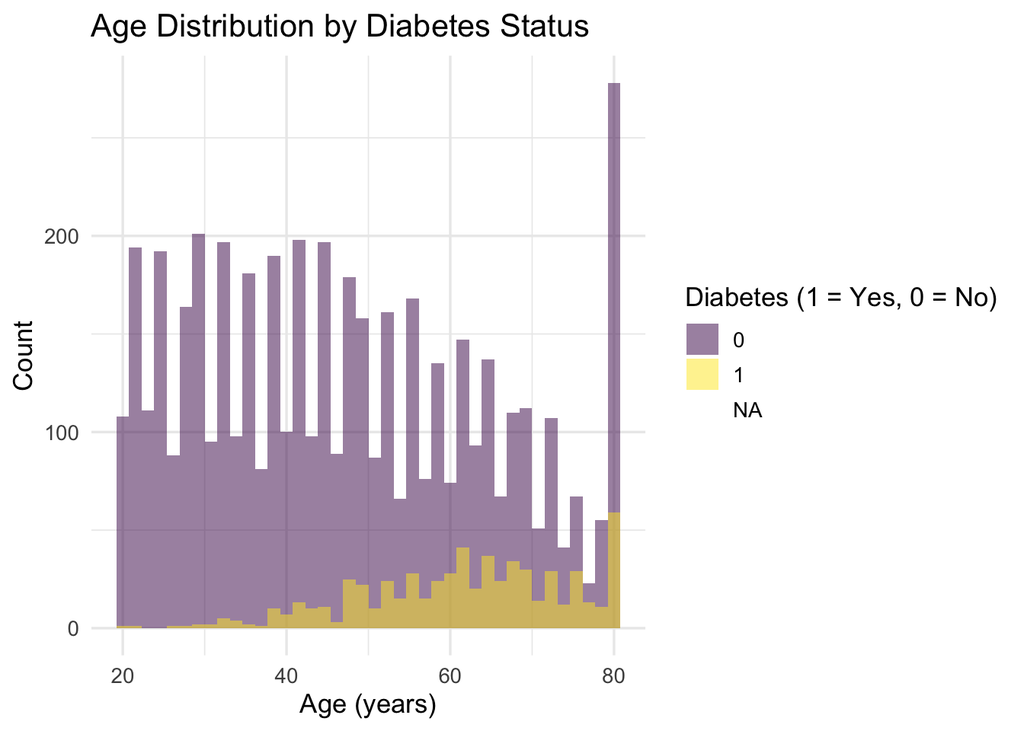

```r
# Age distribution by diabetes status
ggplot(adult, aes(x = age, fill = factor(diabetes_dx))) +
geom_histogram(position = "identity", alpha = 0.5, bins = 40) +
scale_fill_viridis_d(name = "Diabetes (1 = Yes, 0 = No)") +
labs(
title = "Age Distribution by Diabetes Status",
x = "Age (years)",
y = "Count"
)
```

3. Predicted Probability vs BMI (Bayesian)

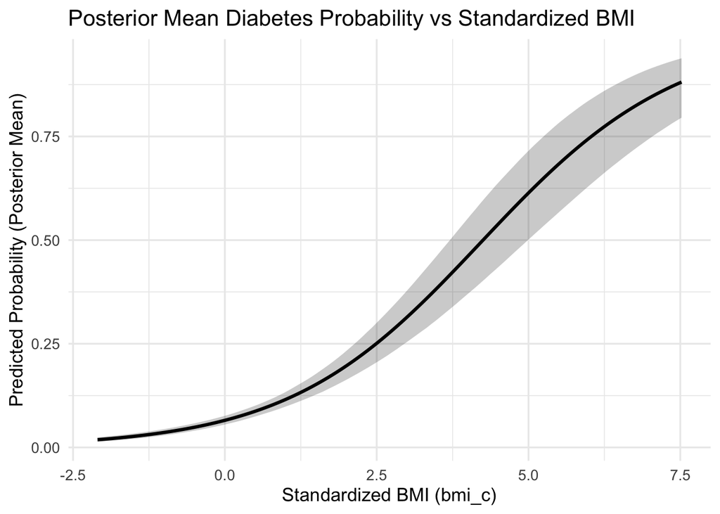

```r
pp_df <- tibble(
bmi_c = seq(min(adult$bmi_c, na.rm = TRUE), max(adult$bmi_c, na.rm = TRUE), length.out = 120),
age_c = mean(adult$age_c, na.rm = TRUE),
sex   = factor("Male", levels = levels(adult$sex)),
race  = factor("NH White", levels = levels(adult$race))
)

# Posterior expected probabilities
pp_pred <- posterior_epred(bayes_fit, newdata = pp_df)
pp_df <- pp_df %>%
mutate(
pred  = apply(pp_pred, 2, mean),
lower = apply(pp_pred, 2, quantile, 0.025),
upper = apply(pp_pred, 2, quantile, 0.975)
)

ggplot(pp_df, aes(x = bmi_c, y = pred)) +
geom_ribbon(aes(ymin = lower, ymax = upper), alpha = 0.25) +
geom_line(size = 1.1) +
labs(
title = "Posterior Mean Diabetes Probability vs Standardized BMI",
x = "Standardized BMI (bmi_c)",
y = "Predicted Probability (Posterior Mean)"
)
```

4. Prior vs Posterior Distributions (Key Coefficients)

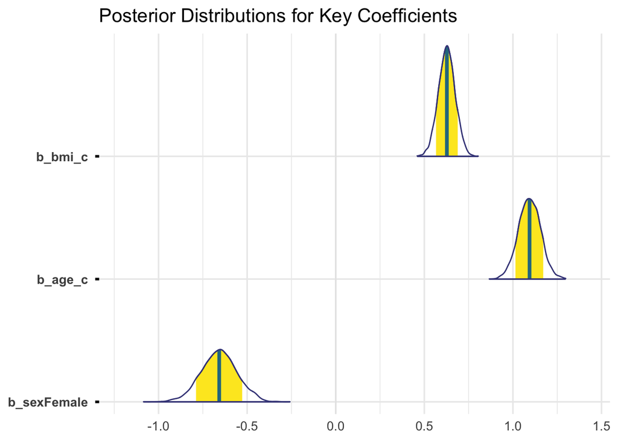

```r
# Posterior coefficient densities
mcmc_areas(
as_draws_df(bayes_fit),
pars = c("b_bmi_c", "b_age_c", "b_sexFemale"),
prob = 0.8
) + ggtitle("Posterior Distributions for Key Coefficients")
```

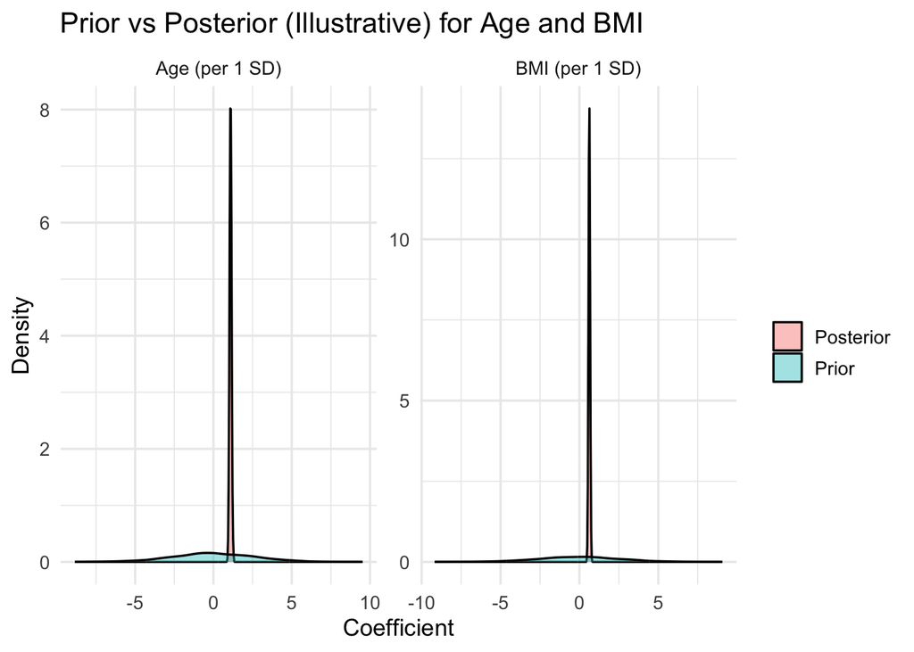

```r
# Simple prior overlays for age & BMI assuming Normal(0, 2.5)
set.seed(1)
prior_draws <- tibble(
term   = rep(c("Age (per 1 SD)", "BMI (per 1 SD)"), each = 4000),
value  = c(rnorm(4000, 0, 2.5), rnorm(4000, 0, 2.5)),
source = "Prior"
)

post_draws <- as_draws_df(bayes_fit) %>%
select(b_age_c, b_bmi_c) %>%
tidyr::pivot_longer(everything(), names_to = "term_raw", values_to = "value") %>%
mutate(
term = dplyr::recode(term_raw, b_age_c = "Age (per 1 SD)", b_bmi_c = "BMI (per 1 SD)"),
source = "Posterior"
) %>%
select(term, value, source)

bind_rows(prior_draws, post_draws) %>%
ggplot(aes(x = value, fill = source)) +
geom_density(alpha = 0.4) +
facet_wrap(~ term, scales = "free") +
labs(
title = "Prior vs Posterior (Illustrative) for Age and BMI",
x = "Coefficient",
y = "Density",
fill = ""
)
```

5. Posterior Predictive Checks

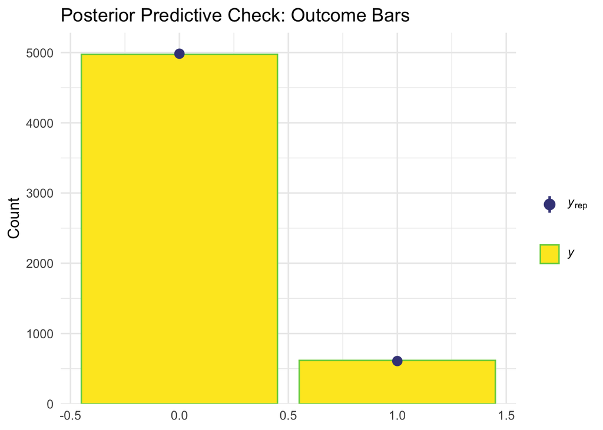

```r
pp_check(bayes_fit, type = "bars") +
ggtitle("Posterior Predictive Check: Outcome Bars")
```

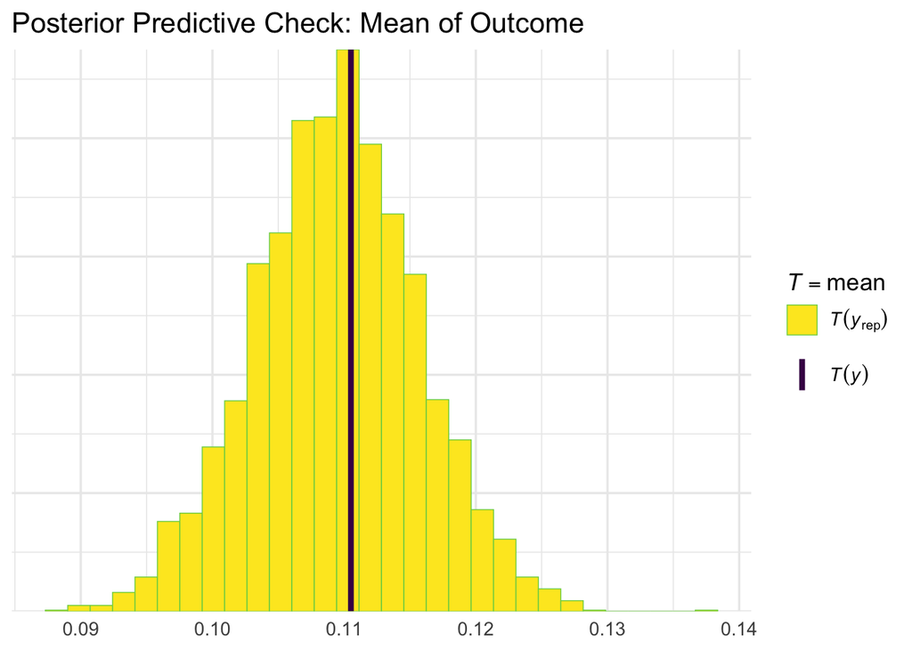

```r
pp_check(bayes_fit, type = "stat", stat = "mean") +
ggtitle("Posterior Predictive Check: Mean of Outcome")
```

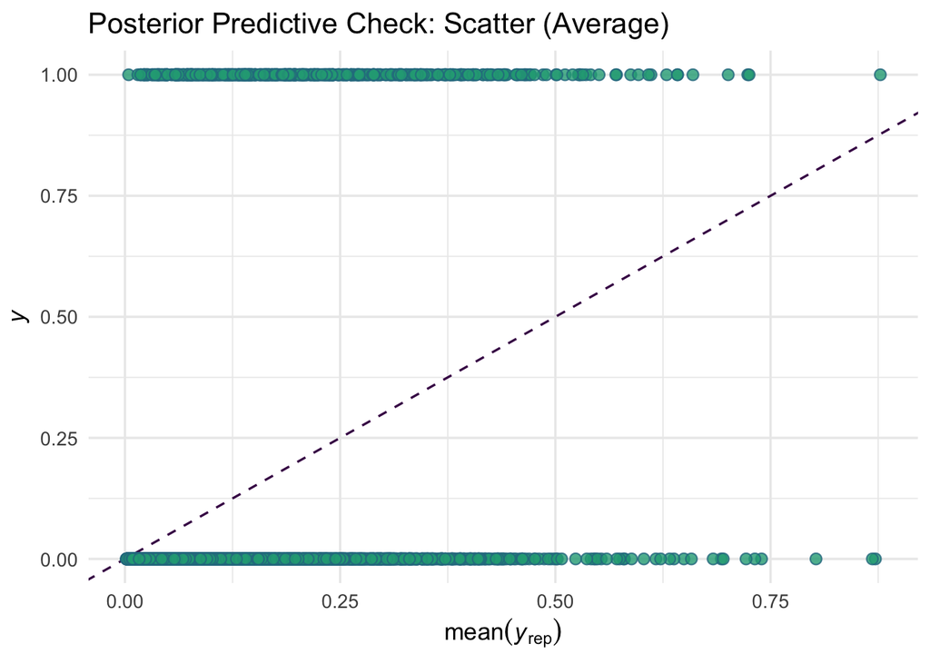

```r
pp_check(bayes_fit, type = "scatter_avg") +
ggtitle("Posterior Predictive Check: Scatter (Average)")
```

6. Observed vs Predicted (Calibration-style view)

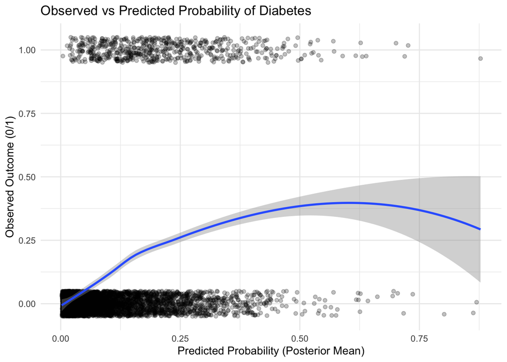

```r
# Posterior expected probabilities for each adult
bayes_pred <- posterior_epred(bayes_fit, newdata = adult, summary = FALSE)

# Robust mean across draws per observation
if (is.matrix(bayes_pred)) {
  # typical shape: draws x N
  pred_prob <- as.numeric(colMeans(bayes_pred, na.rm = TRUE))
} else if (length(dim(bayes_pred)) == 3) {
  # shape: iter x chain x N
  pred_prob <- as.numeric(apply(bayes_pred, 3, mean, na.rm = TRUE))
} else {
  stop("Unexpected shape for posterior_epred() output.")
}

# Add to data frame and plot
adult <- dplyr::mutate(adult, pred_prob = pred_prob)

ggplot(adult, aes(x = pred_prob, y = as.numeric(diabetes_dx))) +
  geom_jitter(height = 0.05, alpha = 0.25) +
  geom_smooth(method = "loess", se = TRUE) +
  labs(
    title = "Observed vs Predicted Probability of Diabetes",
    x = "Predicted Probability (Posterior Mean)",
    y = "Observed Outcome (0/1)"
  ) +
  theme_minimal()
```

7. Posterior vs Population (Survey-weighted) Prevalence

[figure not shown]

```r
# Survey-weighted prevalence (population-representative)
pop_prev <- as.numeric(svymean(~diabetes_dx, nhanes_design_adult, na.rm = TRUE))

# Posterior prevalence from Bayesian model
post_prev <- mean(colMeans(bayes_pred))

bar_df <- tibble(
Source     = c("Survey-weighted (Population)", "Bayesian Posterior"),
Prevalence = c(pop_prev, post_prev)
)

ggplot(bar_df, aes(x = Source, y = Prevalence, fill = Source)) +
geom_col(alpha = 0.85) +
scale_fill_viridis_d(guide = "none") +
labs(
title = "Population vs Posterior Diabetes Prevalence",
y = "Prevalence (Proportion with Diabetes)",
x = NULL
) +
ylim(0, max(bar_df$Prevalence) * 1.15)
```

## References

Abdullah, H., R. Hassan, and B. Mustafa. 2022. “A Review on Bayesian Deep Learning in Healthcare: Applications and Challenges.” *Artificial Intelligence in Medicine* 128: 102312. https://doi.org/10.1016/j.artmed.2022.102312.

Austin, P. C., I. R. White, D. S. Lee, and S. van Buuren. 2021. “Missing Data in Clinical Research: A Tutorial on Multiple Imputation.” *Canadian Journal of Cardiology* 37 (9): 1322–31. https://doi.org/10.1016/j.cjca.2020.11.010.

Baldwin, S. A., and M. J. Larson. 2017. “An Introduction to Using Bayesian Linear Regression with Clinical Data.” *Behaviour Research and Therapy* 98: 58–75. https://doi.org/10.1016/j.brat.2017.05.014.

Chatzimichail, T., and A. T. Hatjimihail. 2023. “A Bayesian Inference-Based Computational Tool for Parametric and Nonparametric Medical Diagnosis.” *Diagnostics* 13 (19): 3135. https://doi.org/10.3390/diagnostics13193135.

Gelman, A., A. Jakulin, M. G. Pittau, and Y. S. Su. 2008. “A Weakly Informative Default Prior Distribution for Logistic and Other Regression Models.” *Annals of Applied Statistics* 2 (4): 1360–83. https://doi.org/10.1214/08-AOAS191.

Hoeting, J. A., D. Madigan, A. E. Raftery, and C. T. Volinsky. 1999. “Bayesian Model Averaging: A Tutorial.” *Statistical Science* 14 (4): 382–417. https://doi.org/10.1214/ss/1009212519.

Klauenberg, K., G. Wübbeler, B. Mickan, P. Harris, and C. Elster. 2015. “A Tutorial on Bayesian Normal Linear Regression.” *Metrologia* 52 (6): 878–92. https://doi.org/10.1088/0026-1394/52/6/878.

Kruschke, J. K., and T. M. Liddell. 2017. “Bayesian Data Analysis for Newcomers.” *Psychonomic Bulletin & Review* 25 (1): 155–77. https://doi.org/10.3758/s13423-017-1272-1.

Liu, Y. M., S. L. S. Chen, A. M. F. Yen, and H. H. Chen. 2013. “Individual Risk Prediction Model for Incident Cardiovascular Disease: A Bayesian Clinical Reasoning Approach.” *International Journal of Cardiology* 167 (5): 2008–12. https://doi.org/10.1016/j.ijcard.2012.05.016.

Luo, C., X. Sun, Y. Zhao, and H. Guo. 2024. “Variable Selection and Model Averaging in Bayesian Additive Regression Trees: A Comparative Study.” *Journal of Computational and Graphical Statistics*. https://doi.org/10.1080/10618600.2024.2401234.

Momeni, F., F. Momeni, A. Moradi, M. Shabani, and B. Amani. 2021. “Bayesian State-Space Modeling of Dynamic COVID-19 Risk Prediction Using Time-Varying Biomarkers.” *Scientific Reports* 11 (1): 20387. https://doi.org/10.1038/s41598-021-99711-7.

National Center for Health Statistics (NCHS). 2014. “National Health and Nutrition Examination Survey (NHANES) 2013–2014 Data Documentation, Codebook, and Frequencies.” U.S. Department of Health; Human Services, Centers for Disease Control; Prevention. https://wwwn.cdc.gov/nchs/nhanes/continuousnhanes/overview.aspx?BeginYear=2013.

Richardson, Robert, and Brian Hartman. 2018. “Bayesian Nonparametric Regression Models for Modeling and Predicting Healthcare Claims.” *Insurance: Mathematics and Economics* 83: 1–8. https://doi.org/10.1016/j.insmatheco.2018.06.002.

Vande Schoot, R., S. Depaoli, R. King, B. Kramer, K. Märtens, M. G. Tadesse, M. Vannucci, et al. 2021. “Bayesian Statistics and Modelling.” *Nature Reviews Methods Primers* 1: 1–26. https://doi.org/10.1038/s43586-020-00001-2.

Zeger, S. L., Z. Wu, Y. Coley, A. T. Fojo, B. Carter, K. O’Brien, P. Zandi, et al. 2020. “Using a Bayesian Approach to Predict Patients’ Health and Response to Treatment.” 272. Johns Hopkins Biostatistics Working Paper Series. https://biostats.bepress.com/jhubiostat/paper272.